# Bank_Personal_Loan_Modelling

Data Description:

```
The file Bank.xls contains data on 5000 customers. The data include
customer demographic information (age, income, etc.), the customer's
relationship with the bank (mortgage, securities account, etc.), and the
customer response to the last personal loan campaign (Personal Loan).
Among these 5000 customers, only 480 (= 9.6%) accepted the personal
loan that was offered to them in the earlier campaign.

Domain: Banking
```

**Context:**

```
This case is about a bank (Thera Bank) whose management wants to
explore ways of converting its liability customers to personal loan
customers (while retaining them as depositors). A campaign that the
bank ran last year for liability customers showed a healthy conversion
rate of over 9% success. This has encouraged the retail marketing
department to devise campaigns with better target marketing to
increase the success ratio with a minimal budget.
```

**Attribute Information:**

```
• ID : Customer ID
• Age : Customer's age in completed years
• Experience : #years of professional experience
• Income : Annual income of the customer ($000)
• ZIP Code : Home Address ZIP code.
• Family : Family size of the customer
• CCAvg : Avg. spending on credit cards per month ($000)
• Education : Education Level. 1: Undergrad; 2: Graduate; 3: Advanced/Professional
• Mortgage : Value of house mortgage if any. ($000)
• Personal Loan : Did this customer accept the personal loan offered in the last campaign?
• Securities Account : Does the customer have a securities account with the bank?
• CD Account : Does the customer have a certificate of deposit(CD) account with the bank?
• Online : Does the customer use internet banking facilities?
• Credit card : Does the customer use a credit card issued by UniversalBank?
```

**Learning Outcomes:**

```
• Exploratory Data Analysis
• Preparing the data to train a model
• Training and making predictions using a classification model
• Model evaluation
```

**Objective:**

```
The classification goal is to predict the likelihood of a liability customer buying personal loans.
```

**Steps and tasks:**

```
1. Read the column description and ensure you understand each attribute well
2. Study the data distribution in each attribute, share your findings (15 marks)
3. Get the target column distribution. Your comments (5 marks)
4. Split the data into training and test set in the ratio of 70:30 respectively (5 marks)
5. Use different classification models (Logistic, K-NN and Naïve Bayes)to predict the likelihood of a customer buying personal loans (25 marks)
6. Print the confusion matrix for all the above models (5 marks)
7. Give your reasoning on which is the best model in this case and why it performs better? (5 marks)
```

# Import Libraries

Import the usual libraries for numpy, pandas and plotting

```python
import pandas as pd
import numpy as np
import matplotlib.pyplot as plt
import seaborn as sns
%matplotlib inline
from sklearn.model_selection import train_test_split
from scipy.stats import zscore
from sklearn import metrics
```

# Studing the data distribution in each column attribute

## Get the Data

```python
## Get it with pandas as a dataframe and display the head
df = pd.read_csv('Bank_Personal_Loan_Modelling.csv')
df.head(10)
```

|  | ID | Age | Experience | Income | ZIP Code | Family | CCAvg | Education | Mortgage | Personal Loan | Securities Account | CD Account | Online | CreditCard |
| --- | --- | --- | --- | --- | --- | --- | --- | --- | --- | --- | --- | --- | --- | --- |
| 0 | 1 | 25 | 1 | 49 | 91107 | 4 | 1.6 | 1 | 0 | 0 | 1 | 0 | 0 | 0 |
| 1 | 2 | 45 | 19 | 34 | 90089 | 3 | 1.5 | 1 | 0 | 0 | 1 | 0 | 0 | 0 |
| 2 | 3 | 39 | 15 | 11 | 94720 | 1 | 1.0 | 1 | 0 | 0 | 0 | 0 | 0 | 0 |
| 3 | 4 | 35 | 9 | 100 | 94112 | 1 | 2.7 | 2 | 0 | 0 | 0 | 0 | 0 | 0 |
| 4 | 5 | 35 | 8 | 45 | 91330 | 4 | 1.0 | 2 | 0 | 0 | 0 | 0 | 0 | 1 |
| 5 | 6 | 37 | 13 | 29 | 92121 | 4 | 0.4 | 2 | 155 | 0 | 0 | 0 | 1 | 0 |
| 6 | 7 | 53 | 27 | 72 | 91711 | 2 | 1.5 | 2 | 0 | 0 | 0 | 0 | 1 | 0 |
| 7 | 8 | 50 | 24 | 22 | 93943 | 1 | 0.3 | 3 | 0 | 0 | 0 | 0 | 0 | 1 |
| 8 | 9 | 35 | 10 | 81 | 90089 | 3 | 0.6 | 2 | 104 | 0 | 0 | 0 | 1 | 0 |
| 9 | 10 | 34 | 9 | 180 | 93023 | 1 | 8.9 | 3 | 0 | 1 | 0 | 0 | 0 | 0 |

```python
# drop the ID column
df = df.drop(labels="ID", axis = 1)
```

```python
## See the data information; showing the entries size, total columns and data types
df.info()
```

```
<class 'pandas.core.frame.DataFrame'>
RangeIndex: 5000 entries, 0 to 4999
Data columns (total 13 columns):
Age                   5000 non-null int64
Experience            5000 non-null int64
Income                5000 non-null int64
ZIP Code              5000 non-null int64
Family                5000 non-null int64
CCAvg                 5000 non-null float64
Education             5000 non-null int64
Mortgage              5000 non-null int64
Personal Loan         5000 non-null int64
Securities Account    5000 non-null int64
CD Account            5000 non-null int64
Online                5000 non-null int64
CreditCard            5000 non-null int64
dtypes: float64(1), int64(12)
memory usage: 507.9 KB
```

```python
## Get basic description of the data
df.describe(include='all').T
```

|  | count | mean | std | min | 25% | 50% | 75% | max |
| --- | --- | --- | --- | --- | --- | --- | --- | --- |
| Age | 5000.0 | 45.338400 | 11.463166 | 23.0 | 35.0 | 45.0 | 55.0 | 67.0 |
| Experience | 5000.0 | 20.104600 | 11.467954 | -3.0 | 10.0 | 20.0 | 30.0 | 43.0 |
| Income | 5000.0 | 73.774200 | 46.033729 | 8.0 | 39.0 | 64.0 | 98.0 | 224.0 |
| ZIP Code | 5000.0 | 93152.503000 | 2121.852197 | 9307.0 | 91911.0 | 93437.0 | 94608.0 | 96651.0 |
| Family | 5000.0 | 2.396400 | 1.147663 | 1.0 | 1.0 | 2.0 | 3.0 | 4.0 |
| CCAvg | 5000.0 | 1.937938 | 1.747659 | 0.0 | 0.7 | 1.5 | 2.5 | 10.0 |
| Education | 5000.0 | 1.881000 | 0.839869 | 1.0 | 1.0 | 2.0 | 3.0 | 3.0 |
| Mortgage | 5000.0 | 56.498800 | 101.713802 | 0.0 | 0.0 | 0.0 | 101.0 | 635.0 |
| Personal Loan | 5000.0 | 0.096000 | 0.294621 | 0.0 | 0.0 | 0.0 | 0.0 | 1.0 |
| Securities Account | 5000.0 | 0.104400 | 0.305809 | 0.0 | 0.0 | 0.0 | 0.0 | 1.0 |
| CD Account | 5000.0 | 0.060400 | 0.238250 | 0.0 | 0.0 | 0.0 | 0.0 | 1.0 |
| Online | 5000.0 | 0.596800 | 0.490589 | 0.0 | 0.0 | 1.0 | 1.0 | 1.0 |
| CreditCard | 5000.0 | 0.294000 | 0.455637 | 0.0 | 0.0 | 0.0 | 1.0 | 1.0 |

*Observations :*

- Impossible data like negative min value for Experience is present, we will treat as missing data later
- Family size is like a categorical data, because of its value and distribution; between 1 and 4

### Data preparation

```python
## Check  Missing values

def missing_values_table(df):
        # Total missing values
        mis_val = df.isnull().sum()

        # Percentage of missing values
        mis_val_percent = 100 * df.isnull().sum() / len(df)

        # Make a table with the results
        mis_val_table = pd.concat([mis_val, mis_val_percent], axis=1)

        # Rename the columns
        mis_val_table_ren_columns = mis_val_table.rename(
        columns = {0 : 'Missing Values', 1 : '% of Total Values'})

        # Sort the table by percentage of missing descending
        mis_val_table_ren_columns = mis_val_table_ren_columns[
            mis_val_table_ren_columns.iloc[:,1] != 0].sort_values(
        '% of Total Values', ascending=False).round(1)

        # Print some summary information
        print ("Your selected dataframe has " + str(df.shape[1]) + " columns.\n"
            "There are " + str(mis_val_table_ren_columns.shape[0]) +
              " columns that have missing values.")

        # Return the dataframe with missing information
        return mis_val_table_ren_columns

missing_values_table(df) ## Pass your dataset name
```

```
Your selected dataframe has 13 columns.
There are 0 columns that have missing values.
```

|  | Missing Values | % of Total Values |
| --- | --- | --- |

```python
# Testing for negative data entries
df.values
```

```
array([[25.,  1., 49., ...,  0.,  0.,  0.],
       [45., 19., 34., ...,  0.,  0.,  0.],
       [39., 15., 11., ...,  0.,  0.,  0.],
       ...,
       [63., 39., 24., ...,  0.,  0.,  0.],
       [65., 40., 49., ...,  0.,  1.,  0.],
       [28.,  4., 83., ...,  0.,  1.,  1.]])
```

```python
df.values.flatten()
```

```
array([25.,  1., 49., ...,  0.,  1.,  1.])
```

```python
sum(n < 0 for n in df.values.flatten())
```

```
52
```

*Observations :*

- we have 52 negative numbers in Experience attribute ( we will need to replace them with the mean of that column)

```python
df['Experience'].mean()
```

```
20.1046
```

```python
# replace negative numbers in Experience attribute with its mean
df.replace(-3, 20.1046, inplace=True)
df.replace(-2, 20.1046, inplace=True)
df.replace(-1, 20.1046, inplace=True)
```

```python
# Check with the code below that every negative number has been replaced with the mean
# df.loc[df['Experience']==20.1046]
```

```python
df.describe(include='all').T
```

|  | count | mean | std | min | 25% | 50% | 75% | max |
| --- | --- | --- | --- | --- | --- | --- | --- | --- |
| Age | 5000.0 | 45.338400 | 11.463166 | 23.0 | 35.0 | 45.0000 | 55.0 | 67.0 |
| Experience | 5000.0 | 20.328688 | 11.253009 | 0.0 | 11.0 | 20.1046 | 30.0 | 43.0 |
| Income | 5000.0 | 73.774200 | 46.033729 | 8.0 | 39.0 | 64.0000 | 98.0 | 224.0 |
| ZIP Code | 5000.0 | 93152.503000 | 2121.852197 | 9307.0 | 91911.0 | 93437.0000 | 94608.0 | 96651.0 |
| Family | 5000.0 | 2.396400 | 1.147663 | 1.0 | 1.0 | 2.0000 | 3.0 | 4.0 |
| CCAvg | 5000.0 | 1.937938 | 1.747659 | 0.0 | 0.7 | 1.5000 | 2.5 | 10.0 |
| Education | 5000.0 | 1.881000 | 0.839869 | 1.0 | 1.0 | 2.0000 | 3.0 | 3.0 |
| Mortgage | 5000.0 | 56.498800 | 101.713802 | 0.0 | 0.0 | 0.0000 | 101.0 | 635.0 |
| Personal Loan | 5000.0 | 0.096000 | 0.294621 | 0.0 | 0.0 | 0.0000 | 0.0 | 1.0 |
| Securities Account | 5000.0 | 0.104400 | 0.305809 | 0.0 | 0.0 | 0.0000 | 0.0 | 1.0 |
| CD Account | 5000.0 | 0.060400 | 0.238250 | 0.0 | 0.0 | 0.0000 | 0.0 | 1.0 |
| Online | 5000.0 | 0.596800 | 0.490589 | 0.0 | 0.0 | 1.0000 | 1.0 | 1.0 |
| CreditCard | 5000.0 | 0.294000 | 0.455637 | 0.0 | 0.0 | 0.0000 | 1.0 | 1.0 |

### Univariate Analysis

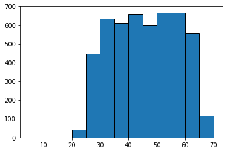

```python
bins = [5,10,15,20,25,30,35,40,45,50,55,60,65,70]
plt.hist(df.Age,bins, edgecolor = 'black')
plt.show()
```

*Observations :*

```python
set(df.Education)
```

```
{1, 2, 3}
```

```python
grouped_data = df.groupby(df.Education)
Education1_data = grouped_data.get_group(1)
Education2_data = grouped_data.get_group(2)
Education3_data = grouped_data.get_group(3)
```

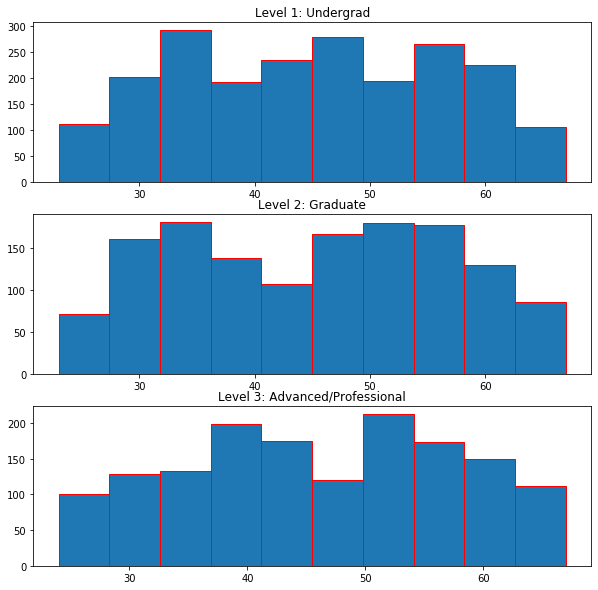

```python
plt.subplots(3,1 ,figsize = (10,10))
plt.subplot(311)
plt.title("Level 1: Undergrad")
plt.hist(Education1_data.Age,10, edgecolor = 'red')
plt.subplot(312)
plt.title("Level 2: Graduate")
plt.hist(Education2_data.Age,10, edgecolor = 'red')
plt.subplot(313)
plt.title("Level 3: Advanced/Professional")
plt.hist(Education3_data.Age,10, edgecolor = 'red')
plt.show()
```

*Observations :*

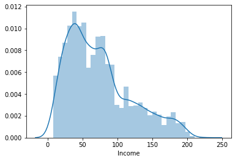

```python
sns.distplot(df.Income)
```

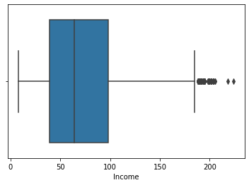

```python
sns.boxplot(df.Income)
```

*Observations :*

- Income graph is right skewed with outliers

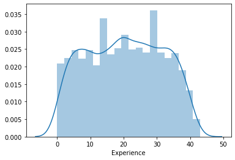

```python
sns.distplot(df.Experience)
```

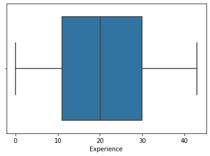

```python
sns.boxplot(df.Experience)
```

*Observations :*

```python
# Lets see the pattern in personal loan acceptance
set(df['Personal Loan'])
```

```
{0, 1}
```

```python
grouped1_data = df.groupby(df['Personal Loan'])
PL0_data = grouped1_data.get_group(0)
PL1_data = grouped1_data.get_group(1)
```

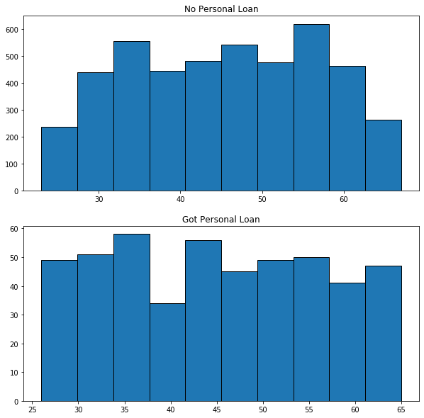

```python
plt.subplots(2,1 ,figsize = (10,10))
plt.subplot(211)
plt.title("No Personal Loan")
plt.hist(PL0_data.Age,10, edgecolor = 'black')
plt.subplot(212)
plt.title("Got Personal Loan")
plt.hist(PL1_data.Age,10, edgecolor = 'black')
plt.show()
```

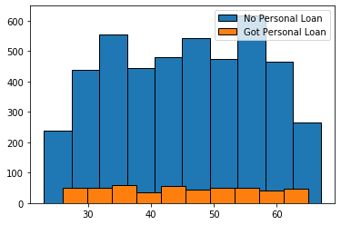

```python
# Draw the histogram on top of one another

plt.hist(PL0_data.Age,10, edgecolor = 'black')
plt.hist(PL1_data.Age,10, edgecolor = 'black')
plt.legend(['No Personal Loan','Got Personal Loan'])
plt.show()
```

*Observations :*

- Persons who are advance in Age and near retirement still accepted personal Loans
- More persons did not accept the personal loans
- Of those that didnot accept this personal loan, those about the Age of 55 were the highest in number
- Of those who accepted the personal loan, those whose Ages are between 35 and 45 were the highest

*Inference :*

- Perhaps those who still accepted personal loan near retirement wanted to settle some pressing needs or start a retirement business or investment
- The ratio of those that received the loan to those that didnot is so small
- And those Age bracket who topped those who accepted the loan may have wanted it to start a life or be in vogue
- However, the bank will have to do more or sell this personal loan on better terms to make more people accept it

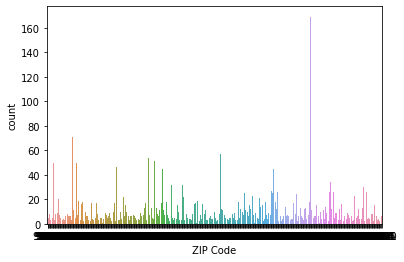

```python
# The distribution of categorical variable can be seen using the count plot.
# Example 1: the distribution of the Zip Code variable (though numbers but they are actually labels)
sns.countplot(df['ZIP Code'])
```

```python
print(df['ZIP Code'].value_counts())
print("\n")
```

```
94720    169
94305    127
95616    116
90095     71
93106     57
92037     54
93943     54
91320     53
91711     52
94025     52
92093     51
90245     50
90024     50
90089     46
91330     46
```

[output cut: 47 more lines]

*Observations :*

- People from three zip codes locations ranked the highest counts (where zip code 94720 stood out clearly), we will see why as we explorer futher. They are:

```
94720    169
94305    127
95616    116
```

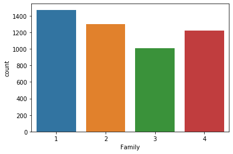

```python
# Example 2: the distribution of the Family variable thought seem numeric the range and the value suggests that this can be seen as a categorical variable
sns.countplot(df.Family)
```

*Observations :*

- Families size of 1 were more in the data set or were sampled more

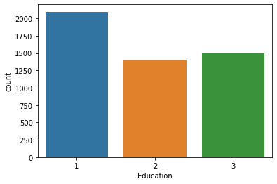

```python
# Example 3: the distribution of the Education variable thought seem numeric, it is actually a categorical label
sns.countplot(df.Education)
```

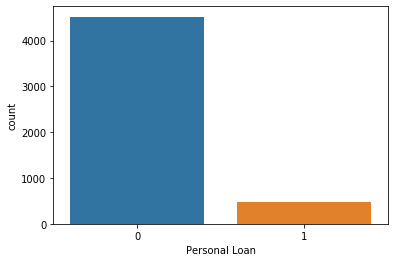

```python
# Example 4: the distribution of the personal loan variable thought seem numeric the range and the value suggests that this can be seen as a categorical variable
sns.countplot(df['Personal Loan'])
```

*Observations :*

- we cannot tell at this stage what influence Education level 1 has an the dataset
- Those who did not accept the personal loans were over 4000

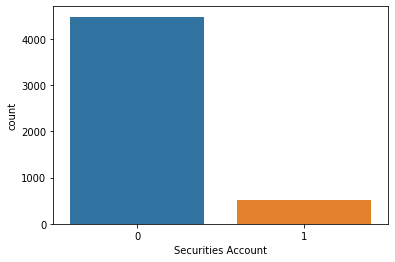

```python
# Example 5: the distribution of the security account variable is a label
sns.countplot(df['Securities Account'])
```

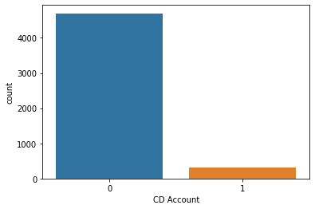

```python
# Example 6: the distribution of the CD variable is a label
sns.countplot(df['CD Account'])
```

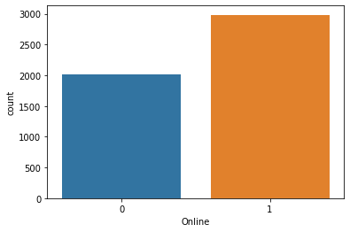

```python
# Example 7: the distribution of the Online variable is a label
sns.countplot(df['Online'])
```

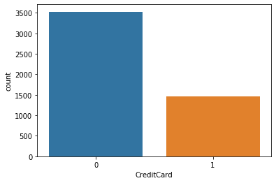

```python
# Example 8: the distribution of the CreditCard variable is a label
sns.countplot(df['CreditCard'])
```

*Observations :*

- There seem to be a correlation between 4 of the 5 label attributes with classes 0(s) and 1(s) except the Online (where more people uses internet banking facilities)

# Getting the target column distribution

## Bivariate Analysis

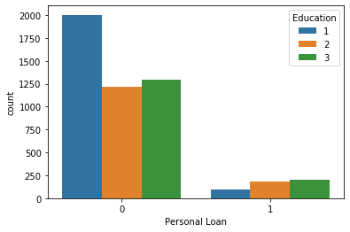

```python
#Bivariate Analysis of categroical variables with countplot and hue
#Example1 : combination of Personal Loan & Education
sns.countplot(df['Personal Loan'], hue = df.Education )
```

*Observations :*

- The number of Undergrad who accepted the personal loan are less compared to the graduate and advanced/professional classes who are almost the same
- Of those that did not accept the personal loan, again graduate and advanced/professional are nearly the same(although advanced/prof topped in both cases). It is note worthy to say that undergrads rejected the loan the most.

*Inference :*

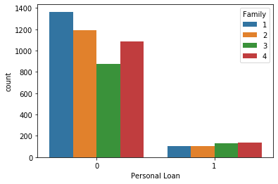

```python
#Example2 : combination of Personal Loan & Family
sns.countplot(df['Personal Loan'], hue = df.Family)
```

*Observations :*

- Of those who rejected the personal loan, the Family of size 3 was list

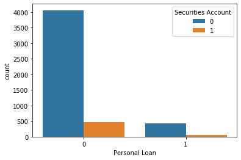

```python
#Example3 : combination of Personal Loan & security account
sns.countplot(df['Personal Loan'], hue = df['Securities Account'])
```

*Observations :*

- Those who did not have security account with the bank rejected most the personal loan and it's number out-weighs the others by far

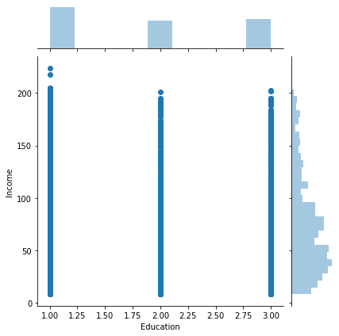

```python
#Bivaraite analysis of Numerical vs Numerical can be done by jointplot
#Example 1 : Education and Income combination
sns.jointplot(x='Education', y ='Income' ,data = df)
```

*Observations :*

- Funny enough undergrads seems to have the highest income

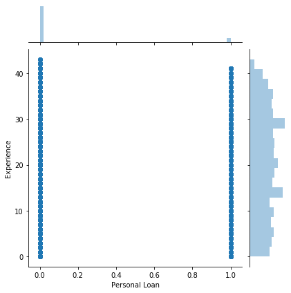

```python
#Example 2 : Personal Loan and Experience combination
sns.jointplot(x=df['Personal Loan'] , y ='Experience' ,data = df)
```

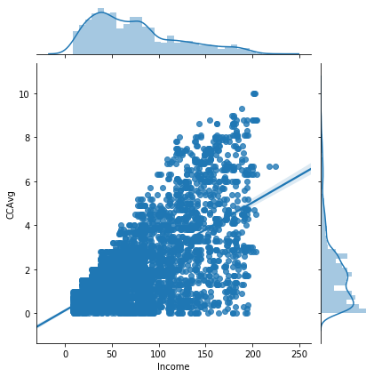

```python
#Example 3 : CCAvg and Personal Loan combination - regression plot
#"scatter" | "reg" | "resid" | "kde" | "hex"
sns.jointplot(x='Income' , y ='CCAvg' ,data = df, kind='reg' )
```

*Observations :*

- There is some correlation between Income and CCAvg (Avg. spending on credit cards per month), which in turn is good chance for Personal Loan acceptance

## Multivariate Analysis

[output not shown]

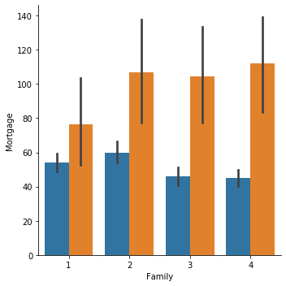

```python
# Multivariate analysis can be done by introducing hue and col in the catplot
#Example 1: Family - Mortgage - Personal Loan combination- bar plot
sns.catplot(x='Family' , y='Mortgage', hue=df['Personal Loan'] , data = df , kind = 'bar')
```

*Observations :*

*Inference :*

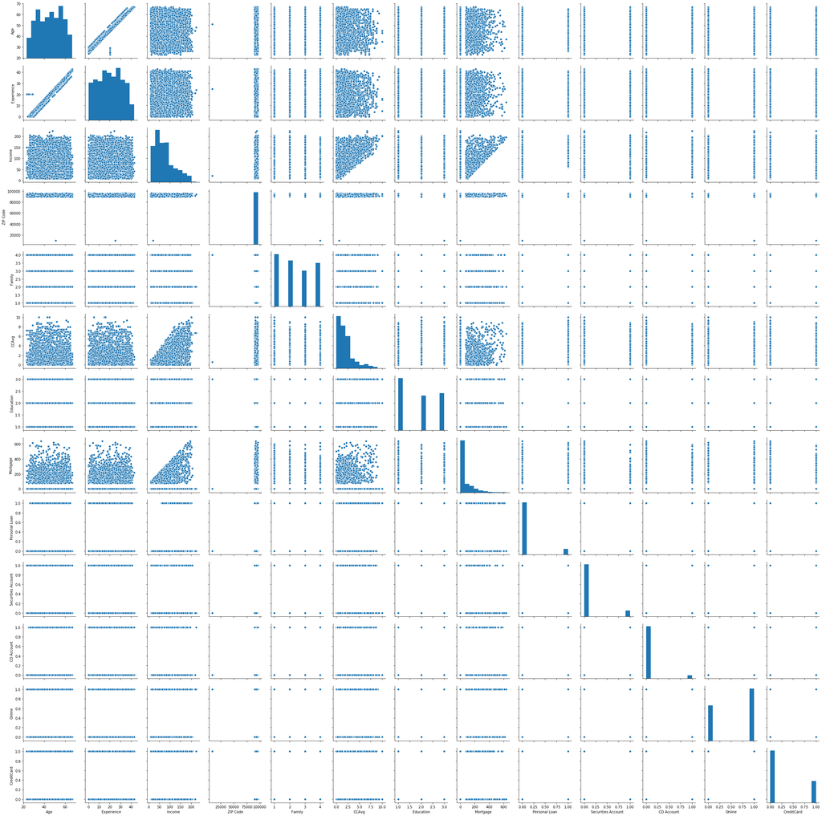

```python
#pairplot gives the distribution and combination of all numerical variables
sns.pairplot(df)
```

```python
#find correlation between the different numerical variables
corr = df.corr()
corr
```

|  | Age | Experience | Income | ZIP Code | Family | CCAvg | Education | Mortgage | Personal Loan | Securities Account | CD Account | Online | CreditCard |
| --- | --- | --- | --- | --- | --- | --- | --- | --- | --- | --- | --- | --- | --- |
| Age | 1.000000 | 0.977008 | -0.055269 | -0.029216 | -0.046418 | -0.052012 | 0.041334 | -0.012539 | -0.007726 | -0.000436 | 0.008043 | 0.013702 | 0.007681 |
| Experience | 0.977008 | 1.000000 | -0.049054 | -0.028488 | -0.045488 | -0.048708 | 0.018097 | -0.013378 | -0.014045 | -0.000462 | 0.005502 | 0.013455 | 0.008833 |
| Income | -0.055269 | -0.049054 | 1.000000 | -0.016410 | -0.157501 | 0.645984 | -0.187524 | 0.206806 | 0.502462 | -0.002616 | 0.169738 | 0.014206 | -0.002385 |
| ZIP Code | -0.029216 | -0.028488 | -0.016410 | 1.000000 | 0.011778 | -0.004061 | -0.017377 | 0.007383 | 0.000107 | 0.004704 | 0.019972 | 0.016990 | 0.007691 |
| Family | -0.046418 | -0.045488 | -0.157501 | 0.011778 | 1.000000 | -0.109275 | 0.064929 | -0.020445 | 0.061367 | 0.019994 | 0.014110 | 0.010354 | 0.011588 |
| CCAvg | -0.052012 | -0.048708 | 0.645984 | -0.004061 | -0.109275 | 1.000000 | -0.136124 | 0.109905 | 0.366889 | 0.015086 | 0.136534 | -0.003611 | -0.006689 |
| Education | 0.041334 | 0.018097 | -0.187524 | -0.017377 | 0.064929 | -0.136124 | 1.000000 | -0.033327 | 0.136722 | -0.010812 | 0.013934 | -0.015004 | -0.011014 |
| Mortgage | -0.012539 | -0.013378 | 0.206806 | 0.007383 | -0.020445 | 0.109905 | -0.033327 | 1.000000 | 0.142095 | -0.005411 | 0.089311 | -0.005995 | -0.007231 |
| Personal Loan | -0.007726 | -0.014045 | 0.502462 | 0.000107 | 0.061367 | 0.366889 | 0.136722 | 0.142095 | 1.000000 | 0.021954 | 0.316355 | 0.006278 | 0.002802 |
| Securities Account | -0.000436 | -0.000462 | -0.002616 | 0.004704 | 0.019994 | 0.015086 | -0.010812 | -0.005411 | 0.021954 | 1.000000 | 0.317034 | 0.012627 | -0.015028 |
| CD Account | 0.008043 | 0.005502 | 0.169738 | 0.019972 | 0.014110 | 0.136534 | 0.013934 | 0.089311 | 0.316355 | 0.317034 | 1.000000 | 0.175880 | 0.278644 |
| Online | 0.013702 | 0.013455 | 0.014206 | 0.016990 | 0.010354 | -0.003611 | -0.015004 | -0.005995 | 0.006278 | 0.012627 | 0.175880 | 1.000000 | 0.004210 |
| CreditCard | 0.007681 | 0.008833 | -0.002385 | 0.007691 | 0.011588 | -0.006689 | -0.011014 | -0.007231 | 0.002802 | -0.015028 | 0.278644 | 0.004210 | 1.000000 |

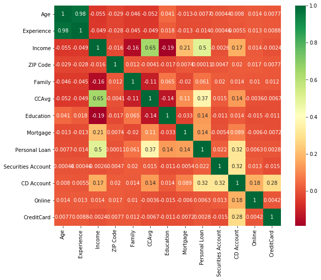

```python
#heatmap helps in visualization of different strengths.Here it is used to visualize correlation.
plt.figure(figsize=(10,8))
sns.heatmap(corr,annot=True,cmap='RdYlGn')
```

*Observations :* We can find high correlation between the following values

- Age and Experience
- Income and CCAvg
- Income and Personal Loan